# Cost-Benefit Analysis Lesson 6 Problem

Dan Killian

Wednesday, March 04, 2015

Marginal Benefit (MB) = 200 - Q  
Travel Cost (TC) = 20  
Congestion Costs (CC) = Q - 100  
Marginal Social Cost (MSC) = TC + CC

```r
MB <- function(q) {
    200 - q
    }
TC <- 20
CC <- function(q) {
    q - 80
    }
MSC = function(TC, CC) {
    TC + CC
    }
```

How many visits would we expect if there were no entry fee for the park?

If we were only dealing with trip cost, then:

200 - q = 20  
q* = 180

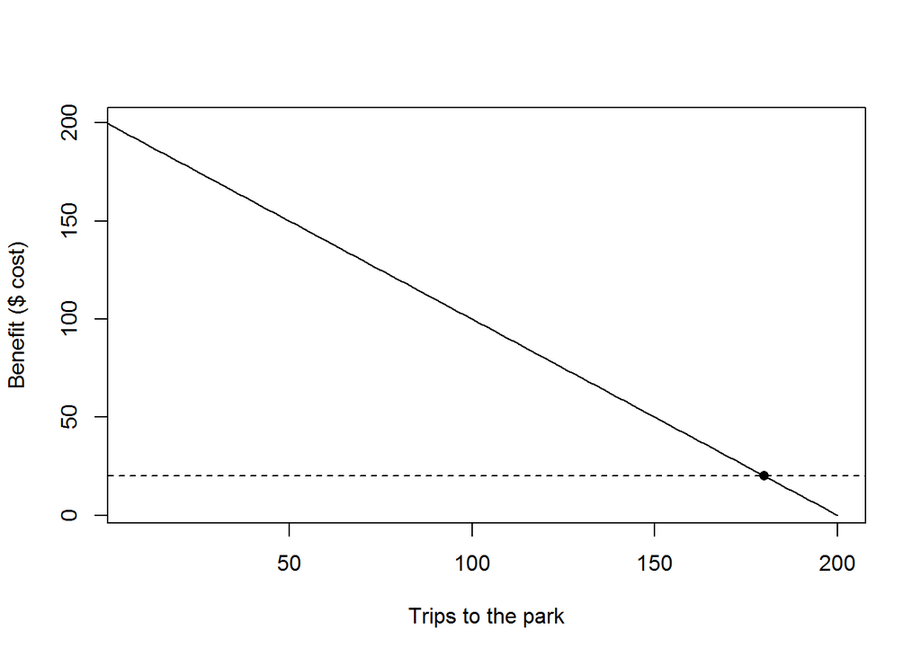

```r
plot(MB, 0, 200, ylim=c(4,200), xlim=c(8,200), xlab=("Trips to the park"), ylab="Benefit ($ cost)")
abline(h=20, lty="dashed")
points(180,20,pch=16)
```

```r
dev.off()
```

2. What is the consumer surplus associated with these visits?

Consumer surplus is the area above optimal price and left of the demand schedule.

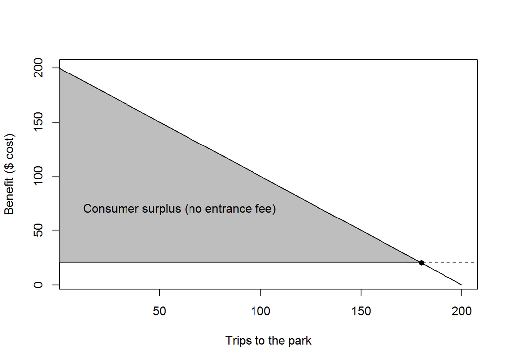

```r
plot(MB, 0, 200, ylim=c(4,200), xlim=c(8,200), xlab=("Trips to the park"), ylab="Benefit ($ cost)")
abline(h=20, lty="dashed")
points(180,20,pch=16)
xcord <- c(0, 180, 0)
ycord <- c(20,20, 200)
polygon(xcord,ycord,col="gray")
text(60, 70, "Consumer surplus (no entrance fee)")
```

```r
dev.off()
```

For linear demand, consumer surplus is 1/2 * x * y

```r
1/2 * 180 * 180
```

```
## [1] 16200
```

$16,200

If we were dealing with a nonlinear demand function, we’d need to integrate over q.

```r
require(mosaic)
F <- antiD(200 - q ~ q)
F
```

```
## function (q, C = 0)
## 200 * q - 1/2 * q^2 + C
```

```r
F(200) - F(20)
```

```
## [1] 16200
```

Same result.

3. What is an efficient fee for the park?

If we are dealing with total social costs, then:

Congestion costs + trip cost = q - 80

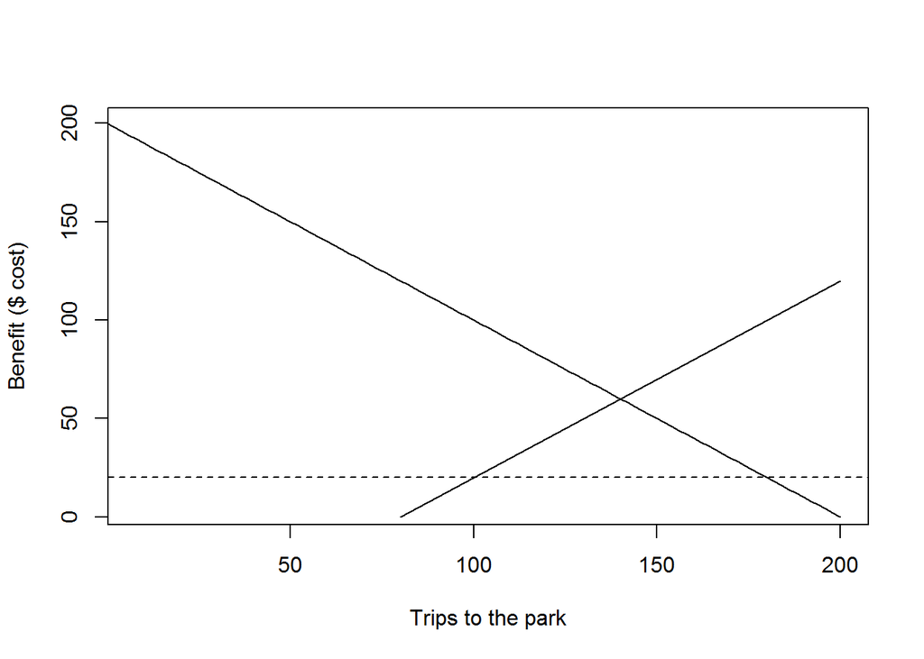

```r
plot(MB, 0, 200, ylim=c(4,200), xlim=c(8,200), xlab=("Trips to the park"), ylab="Benefit ($ cost)")
abline(h=20, lty="dashed")
segments(80,0,200,120)
```

```r
dev.off()
```

Set marginal benefit equal to marginal costs to solve for optimal values

200 - q = q - 80  
2q = 280  
q* = 140  
MB* = 60

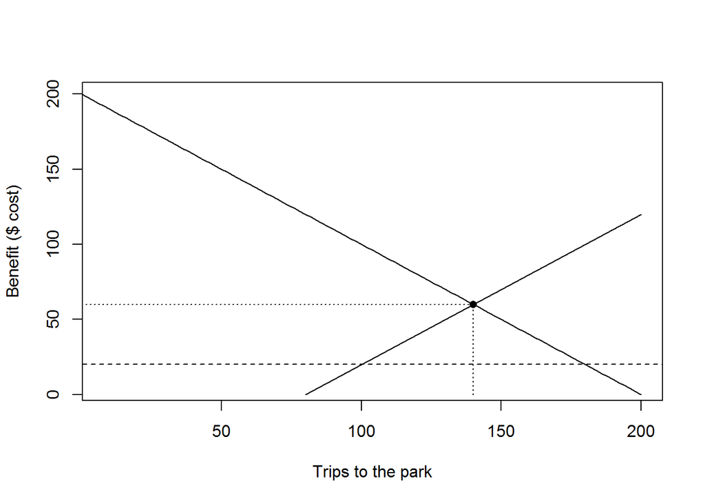

```r
plot(MB, 0, 200, ylim=c(4,200), xlim=c(8,200), xlab=("Trips to the park"), ylab="Benefit ($ cost)")
abline(h=20, lty="dashed")
segments(80,0,200,120)
points(140,60, pch=16)
segments(140,0,140,60, lty="dotted")
segments(0,60,140,60, lty="dotted")
```

```r
dev.off()
```

$60 is the optimal cost, but $20 of that is the trip cost, so the fee imposed by the facility would be $40.

4. How many visits would we see with the efficient fee?

140

5. After a fee is imposed:
   1. What is the consumer surplus?

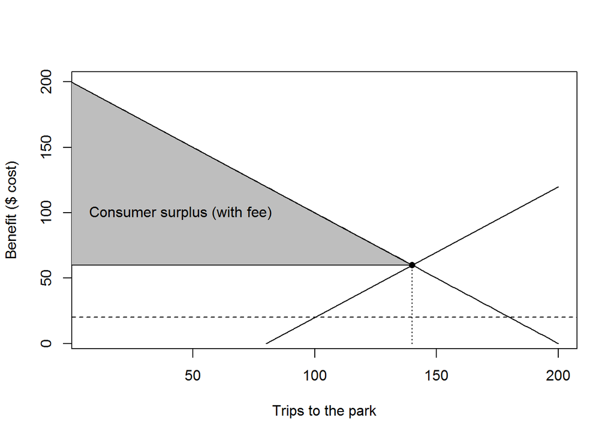

```r
plot(MB, 0, 200, ylim=c(4,200), xlim=c(8,200), xlab=("Trips to the park"), ylab="Benefit ($ cost)")
abline(h=20, lty="dashed")
segments(80,0,200,120)
points(140,60, pch=16)
segments(140,0,140,60, lty="dotted")
segments(0,60,140,60, lty="dotted")
xcord <- c(0,140,0)
ycord <- c(60, 60, 200)
polygon(xcord,ycord,col="gray")
text(45,100, "Consumer surplus (with fee)")
```

```r
dev.off()
```

```r
1/2*140*140
```

```
## [1] 9800
```

```r
F(200) - F(60)
```

```
## [1] 9800
```

$9,800

```
b.  What is the government revenue?
```

Government revenue is the portion of the original consumer surplus that now goes toward the fee.

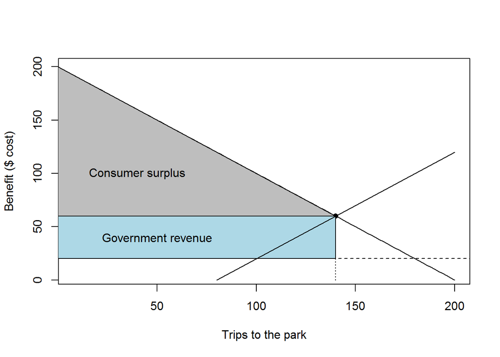

```r
plot(MB, 0, 200, ylim=c(4,200), xlim=c(8,200), xlab=("Trips to the park"), ylab="Benefit ($ cost)")
abline(h=20, lty="dashed")
points(140,60, pch=16)
segments(140,0,140,60, lty="dotted")
segments(0,60,140,60, lty="dotted")
xcord <- c(0,140,0)
ycord <- c(60, 60, 200)
polygon(xcord,ycord,col="gray")
text(40, 100, "Consumer surplus")
xcord2 <- c(0,140,140,0)
ycord2 <- c(60,60,20,20)
polygon(xcord2, ycord2, col="light blue")
segments(80,0,200,120)
text(50, 40, "Government revenue")
```

```r
dev.off()
```

```r
40*140
```

```
## [1] 5600
```

Price $40 * visitors 140 = $5,600

```
c.  What is the deadweight loss that has been avoided?
```

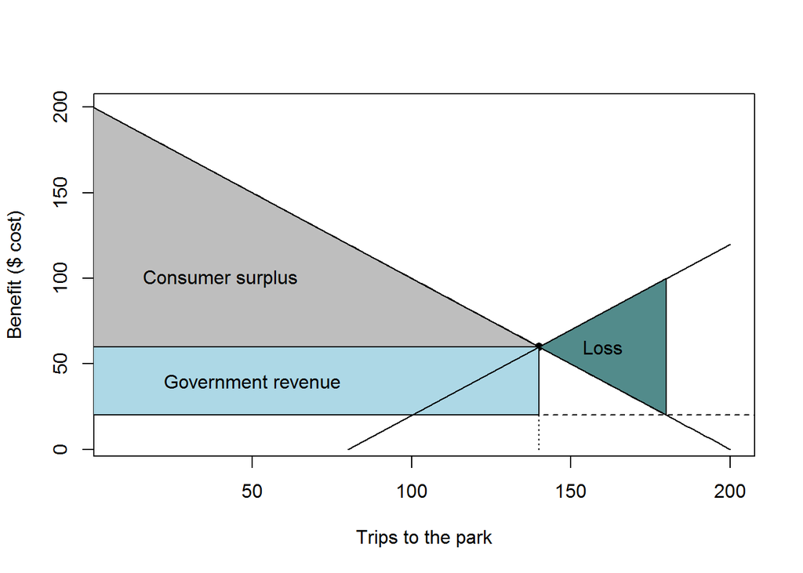

```r
plot(MB, 0, 200, ylim=c(4,200), xlim=c(8,200), xlab=("Trips to the park"), ylab="Benefit ($ cost)")
abline(h=20, lty="dashed")
points(140,60, pch=16)
segments(140,0,140,60, lty="dotted")
segments(0,60,140,60, lty="dotted")
xcord <- c(0,140,0)
ycord <- c(60, 60, 200)
polygon(xcord,ycord,col="gray")
text(40, 100, "Consumer surplus")
xcord2 <- c(0,140,140,0)
ycord2 <- c(60,60,20,20)
polygon(xcord2, ycord2, col="light blue")
segments(80,0,200,120)
text(50, 40, "Government revenue")
segments(180,20,180,100, lty="dotted")
xcord3 <- c(180,180,140)
ycord3 <- c(20,100,60)
polygon(xcord3, ycord3, col="darkslategray4")
text(160, 60, "Loss")
```

```r
dev.off()
```

```r
1/2*(180-140)*(100-20)
```

```
## [1] 1600
```

```r
F(180) - F(140)
```

```
## [1] 1600
```

$1,600

In the absence of a fee, visitors in the “Loss” area do not enjoy any surplus (benefit) due to congestion.

```
d.    What are the avoided congestion costs?
```

Congestion costs would be visits after the optimal point of 140, up to the trip cost optimum of 180, bounded by the optimal prices of $60 and $20.

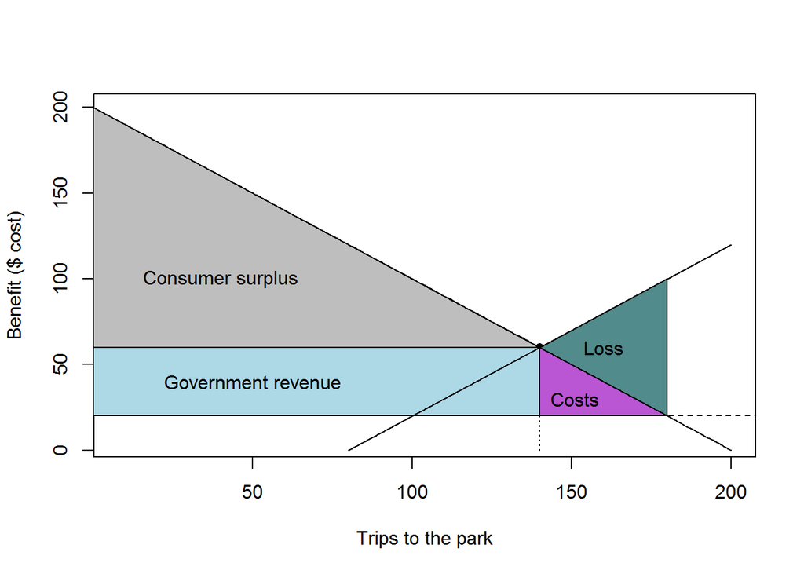

```r
plot(MB, 0, 200, ylim=c(4,200), xlim=c(8,200), xlab=("Trips to the park"), ylab="Benefit ($ cost)")
abline(h=20, lty="dashed")
points(140,60, pch=16)
segments(140,0,140,60, lty="dotted")
segments(0,60,140,60, lty="dotted")
xcord <- c(0,140,0)
ycord <- c(60, 60, 200)
polygon(xcord,ycord,col="gray")
text(40, 100, "Consumer surplus")
xcord2 <- c(0,140,140,0)
ycord2 <- c(60,60,20,20)
polygon(xcord2, ycord2, col="light blue")
segments(80,0,200,120)
text(50, 40, "Government revenue")
segments(180,20,180,100, lty="dotted")
xcord3 <- c(180,180,140)
ycord3 <- c(20,100,60)
polygon(xcord3, ycord3, col="darkslategray4")
text(160, 60, "Loss")
xcord4 <- c(140,180,140)
ycord4 <- c(60,20,20)
polygon(xcord4, ycord4, col="mediumorchid")
text(151, 30, "Costs")
```

```r
dev.off()
```

```r
1/2*(180-140)*(60-20)
```

```
## [1] 800
```

$800 in congestion costs from $140-$180 below the demand curve, plus $1,600 from the deadweight loss ($140-$180 above the demand curve). So $2,400 in congestion costs are avoided.

6. What are the net benefits from imposing a fee?

Without fee:

Benefit: Consumer surplus $16,200

With fee:

Benefit: Consumer surplus $9,800  
Government revenue $5,600

Costs: Congestion $800

Net benefit $14,600

The net benefit of imposing a fee is $14,600 - $13,000 = $1,600

This is the same as the deadweight loss that was avoided by imposing a fee